# Analyze Hanxi’s single stain flow results

Bin He, originally by Hanxi Tang

2023-10-20 (updated 2023-10-20)

# Background

This is the flow cytometry data for SYTO9 single stained and SYTO9+PI dual stained cells. The samples are mixures of live and 1M H2O2 killed *C. glabrata* cells. The goal of this experiment is to determine

1. Whether SYTO9 stainining is different between live and dead cells
2. Whether SYTO9 emission has significant spillover in the BL3 channel, which we use to measure PI

```r
require(tidyverse)
require(flowCore)
require(flowClust)
require(openCyto)
require(ggcyto)
require(cowplot)
```

```r
old <- theme_set(theme_minimal())
```

# Import data

```r
data.path = "/Volumes/rdss_bhe2/User/Hanxi Tang/Flow Cytometry/101823_+-PI Filters/"
fs <- read.flowSet(path = data.path, transformation = FALSE,  # the original values are already linearized.
                   emptyValue = FALSE,  alter.names = TRUE,   # change parameter names to R format
                   column.pattern = ".H|FSC|SSC") # only load the height variables for the fluorescent parameters
fs0 <- fs # make a copy of the original data in case of corruption
```

Specify the flowSet phenoData

# Exploratory Data Analysis

Let’s take one dataset and visualize the changes in the various parameters

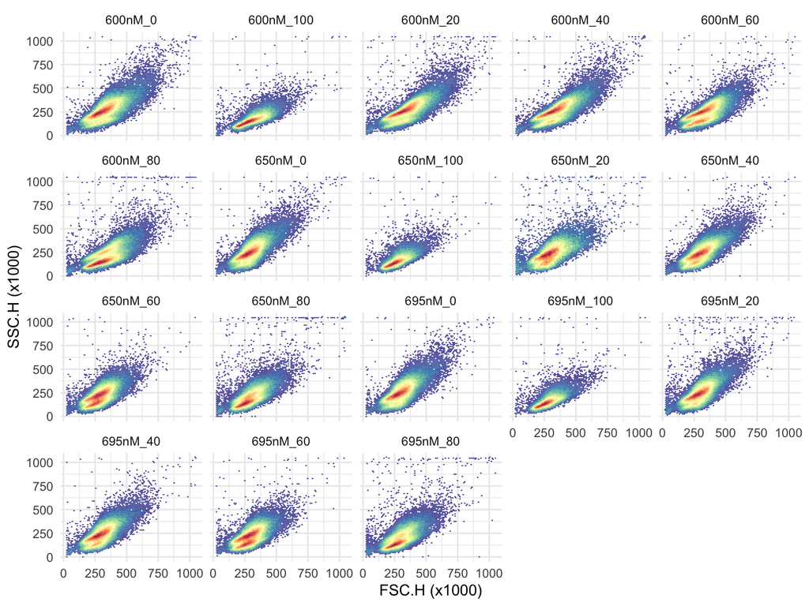

```r
sub <- fs[pData(fs)$species == "Cg"]
mult_format <- list(
  scale_y_continuous(name = "SSC.H (x1000)", labels = function(l) {l/1000}),
  scale_x_continuous(name = "FSC.H (x1000)", labels = function(l) {l/1000})
)
p <- ggcyto(sub, aes(x = "FSC.H", y = "SSC.H")) +
  geom_hex(aes(fill = after_stat(ncount)), bins = 80) +
  #scale_fill_gradientn(colours = rev(RColorBrewer::brewer.pal(11, "Spectral"))) +
  mult_format + facet_wrap(~paste(filter, dead, sep = "_"), scales = "fixed")
p
```

```r
cell.filter <- rectangleGate(filterId = "cell",
                             "FSC.H" = c(125E3, 100E4),
                             "SSC.H" = c(0, 750E3))
# constructor for a list of filters
#cell.gates <- sapply(sampleNames(fs), function(sn)cell.filter)
p1 <- ggcyto(sub, aes(x = "FSC.H", y = "SSC.H")) + geom_hex(bins = 80) +
  geom_gate(cell.filter) +
  facet_wrap(~H2O2, labeller = "label_both") + theme_minimal()
p1 + scale_y_continuous(name = "SSC.H (x1000)", labels = function(l) {l/1000}) +
  scale_x_continuous(name = "FSC.H (x1000)", labels = function(l) {l/1000})
```

[output not shown]

Remove the outliers

```r
sub1 <- Subset(sub, cell.filter)
p1 <- ggcyto(sub1, aes(x = "FSC.H", y = "SSC.H")) + geom_hex(bins = 80) +
  facet_wrap(~H2O2, labeller = "label_both") + theme_minimal()
p1 + scale_y_continuous(name = "SSC.H (x1000)", labels = function(l) {l/1000}) +
  scale_x_continuous(name = "FSC.H (x1000)", labels = function(l) {l/1000})
```

[output not shown]

Try Identifying the two clusters

```r
tmp.dat <- sub1[[which(pData(sub)$H2O2 == 2)]]
tmp.res <- flowClust(
  tmp.dat,
  varNames = c("FSC.H", "SSC.H"),
  K = 2,
  B = 500
  )
```

```r
summary(tmp.res)
def.par <- par(no.readonly = TRUE) # save defaults, for resetting...
layout(matrix(c(1,2), ncol = 2))   # divide the figure into two columns
plot(tmp.res, data = tmp.dat, level = 0.8, z.cutoff = 0)
plot(density(tmp.res, data = sub[[4]]), type = "image")
par(def.par)
```

[output not shown]

Let’s split the two populations and compare their fluorescence levels

```r
# creates a filter object to store all settings, but doesn't perform the clustering
tmp.filter <- tmixFilter(filterId = "fsc-ssc", parameters = c("FSC.H", "SSC.H"), K = 2, B = 500)
# implement the actual clustering
tmp.res2 <- filter(tmp.dat, tmp.filter)
```

```r
tmp.split <- split(tmp.dat, tmp.res2, population = list(ssc.h = 1, ssc.l = 2)) %>% as("flowSet")
# get the MFI for each subset
tmp.median <- fsApply(tmp.split, each_col, median)
tmp.median
ggcyto(tmp.split, aes(x = "FSC.H", y = "SSC.H")) + geom_hex(bins = 80) + theme_minimal()
ggcyto(tmp.split, aes(x = "BL1.H", y = "BL3.H")) + geom_hex(bins = 80) + scale_x_logicle() + scale_y_logicle() +
  theme_minimal()
```

[output not shown]

To examine the low-staining pop further, I will make a gate on BL1.H and BL3.H

```r
unstained.filter <- rectangleGate(filterId = "unstained",
                                  list("BL1.H" = c(0, 100),
                                       "BL3.H" = c(0, 100)))
unstained.res <- filter(tmp.dat, unstained.filter)
unstained.pop <- split(tmp.dat, unstained.res) %>% as("flowSet")
ggcyto(unstained.pop, aes(x = "FSC.H")) + geom_density(aes(color = factor(name)), linewidth = 1.5) +
  scale_color_manual("Unstained", values = c("unstained-" = "gray20", "unstained+" = "red")) +
  facet_wrap(~NULL) + theme_minimal(base_size = 16)
```

[output not shown]

```r
p2 <- ggcyto(sub1, aes(x = BL1.H, y = BL3.H)) +
  geom_hex(aes(fill = after_stat(ncount)), bins = 80) +
  facet_wrap(~H2O2, labeller = "label_both") + theme_minimal()
p2 + scale_y_logicle() + scale_x_logicle()
```

[output not shown]

Extract MFI for BL1.H across all flowFrames

```r
tmp <- fsApply(fs, each_col, median, use.exprs = TRUE)
```

# Gatting

```r
outlier.gate <- rectangleGate(filterId = "-outlier", "FSC.H" = c(1.2e5, 1e6), "SSC.H" = c(1e2, 1e6))
ggcyto(fs, aes(x = FSC.H, y = SSC.H), subset = "root") +
  geom_hex(bins = 64) + geom_gate(outlier.gate) + facet_wrap(~name, ncol = 2)# + ggcyto_par_set(limits = "instrument")
```

Add this gate to the GatingSet

```r
gs <- GatingSet(fs) # create a GatingSet
gs_pop_add(gs, outlier.gate, parent = "root")
recompute(gs)
```

Let’s examine how this gate intersected with the FSC.H vs FSC.W plot (for singlets)

```r
p1 <- ggcyto(gs[[1]], aes(x = FSC.H, y = FSC.W), subset = "root") + geom_hex(bins = 128)
p2 <- ggcyto(gs[[1]], aes(x = FSC.H, y = FSC.W), subset = "-outlier") + geom_hex(bins = 128)
plot_grid(as.ggplot(p1), as.ggplot(p2), ncol = 2)
```

[output not shown]

Gate for singlets

```r
scPars <- ggcyto_par_set(limits = list(x = c(0,1e6), y = c(30,300)))
ex <- Subset(fs[[1]], outlier.gate)
#singlet.gate <- gate_flowclust_2d(ex, "FSC.H", "FSC.W", filterId = "singlet", K = 2, quantile = 0.8)
# switch to a polygongate
polygon <- matrix(c(1e5, 1e5, 1e6, 1e6, 60, 75, 135,60), ncol = 2)
colnames(polygon) <- c("FSC.H", "FSC.W")
singlet.gate <- polygonGate(filterId = "singlet", boundaries = polygon)
ggcyto(ex, aes(x = FSC.H, y = FSC.W)) + geom_hex(bins = 128) + geom_gate(singlet.gate) + geom_stats() + scPars
```

Add this gate to the gatingSet

Visualize the data

```r
ggcyto(gs[sample(shortNames,8)], aes(x = BL1.H, y = BL3.H), subset = "-outlier") + geom_hex(bins = 64) +
  facet_wrap(~name, ncol = 4) + scale_x_logicle() + scale_y_logicle() + theme_bw()
```

# Gate for Dead population

> Dead population is defined based on 1M treated sample.

```r
scPars <- ggcyto_par_set(limits = list(x = c(0,1e6), y = c(0,1e6)))
ex <- Subset(fs[[15]], singlet.gate)
polygon <- matrix(c(0, 0, 10^3.1, 10^3.1, 10^2.9, 10^2.4, 10^1.8,
                    10^3.2, 10^3.5, 1e4, 10^3.4, 10^3, 10^2.6, 10^2.2), ncol = 2)
colnames(polygon) <- c("BL1.H", "BL3.H")
dead.gate <- polygonGate(filterId = "dead", boundaries = polygon)
ggcyto(ex, aes(x = BL1.H, y = BL3.H)) + geom_hex(bins = 128) + geom_gate(dead.gate) + geom_stats() + scPars + scale_x_logicle() + scale_y_logicle()
```

[output not shown]

Add this gate to the gatingSet

# Gate for Live population

> live population is gated based on the mock treated sample

```r
scPars <- ggcyto_par_set(limits = list(x = c(0,1e6), y = c(0,1e6)))
ex <- Subset(fs[[12]], singlet.gate)
polygon1 <- matrix(c(1e2, 1e2, 10^2.5, 10^4, 1e3,
                    0, 1e2, 10^2.1, 10^3, 0), ncol = 2)
colnames(polygon1) <- c("BL1.H", "BL3.H")
live.gate <- polygonGate(filterId = "live", boundaries = polygon1)
ggcyto(ex, aes(x = BL1.H, y = BL3.H)) + geom_hex(bins = 128) + geom_gate(live.gate) + geom_stats() + scPars + scale_x_logicle() + scale_y_logicle()
```

[output not shown]

Add this gate to the gatingSet

# Gate for Unstained population

> Unstained population is defined as population below 10^2 in both channels (in the noise range).

```r
scPars <- ggcyto_par_set(limits = list(x = c(0,1e6), y = c(0,1e6)))
ex <- Subset(fs[[7]], singlet.gate)
polygon2 <- matrix(c(0, 1e2, 1e2, 0,
                    0, 0, 1e2, 1e2), ncol = 2)
colnames(polygon2) <- c("BL1.H", "BL3.H")
unstained.gate <- polygonGate(filterId = "unstained", boundaries = polygon2)
ggcyto(ex, aes(x = BL1.H, y = BL3.H)) + geom_hex(bins = 128) + geom_gate(unstained.gate) + geom_stats() + scPars + scale_x_logicle() + scale_y_logicle()
```

Add this gate to the gatingSet

# Gate for stained population

> stained population is defined based populatio above 10^2 in both channels.

```r
scPars <- ggcyto_par_set(limits = list(x = c(0,1e6), y = c(0,1e6)))
ex <- Subset(fs[[7]], singlet.gate)
polygon3 <- matrix(c(1e2, 1e6, 1e6, 1e2,
                    0, 0, 1e6, 1e6), ncol = 2)
colnames(polygon3) <- c("BL1.H", "BL3.H")
stained.gate <- polygonGate(filterId = "stained", boundaries = polygon3)
ggcyto(ex, aes(x = BL1.H, y = BL3.H)) + geom_hex(bins = 128) + geom_gate(stained.gate) + geom_stats() + scPars + scale_x_logicle() + scale_y_logicle()
```

Add this gate to the gatingSet

# Gate for red positive population

> Red population is defined as red positive events in the stained population. It’s gated based on the 1M treated population

```r
scPars <- ggcyto_par_set(limits = list(x = c(0,1e6), y = c(0,1e6)))
ex <- Subset(fs[[16]], stained.gate)
polygon4 <- matrix(c(1e2, 1e6, 1e6, 1e2,
                    10^2.5, 10^2.5, 1e6, 1e6), ncol = 2)
colnames(polygon4) <- c("BL1.H", "BL3.H")
RP.gate <- polygonGate(filterId = "RP", boundaries = polygon4)
ggcyto(ex, aes(x = BL1.H, y = BL3.H)) + geom_hex(bins = 128) + geom_gate(RP.gate) + geom_stats() + scPars + scale_x_logicle() + scale_y_logicle()
```

Add this gate to the gatingSet

# Extract event counts, write into tibble, export into csv

```r
smaller <- Subset(fs, live.gate)
summary(smaller)
```

[output not shown]

```r
mydata %>%
  mutate(Treatment = factor(Treatment, levels = c("2 mM", "4 mM", "6 mM", "8 mM", "10 mM", "20 mM", "40 mM", "60 mM", "80 mM", "100 mM"))) %>%
ggplot(aes(x = Treatment, y = Percent_Live)) +
  geom_boxplot()+
  geom_point()+
  theme_minimal() +
  labs(x = "Treatment Hydrogen Peroxide Concentration (mM)",
       y = "Gated Live Population Percentage")
```

# Calculate R^2 for each correlation

```r
sample <- c(sample)

lm.res <- mydata %>%
  as.data.frame() %>%
  lm(CFU_Survival ~ Percent_Live, data = .)

summary(lm.res)

lm.res2 <- mydata %>%
  as.data.frame() %>%
  lm(CFU_Survival ~ Percent_Dead, data = .)

summary(lm.res2)

lm.res3 <- mydata %>%
  as.data.frame() %>%
  lm(CFU_Survival ~ Percent_RedPos_Stained, data = .)

summary(lm.res3)

lm.res4 <- mydata %>%
  as.data.frame() %>%
  lm(CFU_Survival ~ Percent_Red_neg, data = .)

summary(lm.res4)
```

[output not shown]

```r
library(ggplot2)
library(viridis)
ggplot(mydata, aes(x = Percent_Live, y = CFU_Survival)) +
  geom_point(aes(color = Treatment), size = 3) +
  stat_smooth(method = "lm") +
  labs(x = "Gated Live Population Percentage",
       y = "CFU Survival")  +
  theme_minimal() +
  theme(axis.title = element_text(size = 14, face = "bold"),
        axis.text = element_text(size = 14, face = "bold"),
        axis.line = element_line(color = "black"),
        legend.text = element_text(size = 14, face = "bold"),   # Set legend label size and boldness
        legend.title = element_text(size = 14, face = "bold"))  # Set legend title size and boldness
```

[output not shown]

```r
ggplot(mydata_filtered, aes(x = Percent_Dead, y = CFU_Survival)) +
  geom_point()+ scale_y_sqrt()
```